# Bayesian Linear Regression

Evan Carey, created for BH Analytics

# Introduction to Regression

- Heart of modern frequentist statistics
- Explore relationships between and an
- Many different types of regression
- Some examples of regression you currently use
  - What type of data?
  - What size of data?
  - What are your outputs?

# Types Regression

- OLS Regression, or simple linear regression
- Multiple Linear Regression
- Logistic Regression
- Poisson Regression
- Cox Time to Event Analysis
- Mixed Effects (or hierarchical?)
- Repeated Measures

# General Regression Strategy

- Collect appropriate data
- Identify Outcomes / predictors
- Investigate “shape” of data
- Consider appropriate functional form
- Apply prior knowledge
- Select “best” model and variables
- Check model for validity (residuals, etc)
- Apply model
- Predict new results
- R has great functionality for all of this

# Regression Strategy from a Bayesian Perspective

- Collect data
- Perform EDA
- Decide on a model (specify distribution for outcome and the parameters in the model)
- Decide on priors for any parameters
- Estimate the posterior using MCMC
- Evaluate your model fit and consider other models
- Summarize the model results by drawing from the posterior (predict new results)

# OLS Regression (Linear Regression)

- “Basic” regression
- Easy to learn conceptually, applies to other
- Outcome is a continuous variable
- Predicting weight
- Predicting monetary values
- Predicting Lab tests
- What are the assumptions of ordinary linear regression?

# General Linear Model

- The OLS linear model is actually type of general linear model (the simplest type). The general linear model framework with an identify link (more on this later) looks like this:

$$\text{Y}_i \sim \text{Normal}(\eta, \sigma^2)$$

$$\eta = \beta _0 + \beta _1 X_1 + \beta _2 X_2...\beta _i X_i$$

-And the normal distribution is defined by:

$$f(x \mid \mu, \sigma^2) = \frac{1}{\sqrt{2\pi\sigma^2}}e^{-\frac{(x-\mu)^2}{2\sigma^2}}$$

- If the outcome is continuous, this is usually one of the first models we would consider.

# Assumptions of OLS Regression

- Assumptions *this is key*
- Normality
- Independence
- Linearity
- Homoscedasticity (pull this off in scrabble)

# Formulas in R

- We can express these models via formulas in R, using something like the following:

`model <- lm(formula, data)`

- Formula is a special object in R

`response variable ~ explanatory variable(s)`

`Y ~ X1 + X2 + X3 + X4...`

# Formula syntax

| op |  | description |
| --- | --- | --- |
| `+` | `+ x` | include this variable |
| `-` | `- x` | delete this variable |
| `:` | `x:z` | include interaction |
| `*` | `x*z` | include interaction and lower |
| `I` | `I(x*z)` | Resolve expression before model |
| `1` | `- 1` | intercept: delete the intercept |

# The CO2 dataset

- We will use the CO2 dataset as a modeling example in this session. Please review the description of this data if you have not used it before. `help(CO2)`
- Import the dataset and do a little bit of exploration to better understand it.
- The outcome of interest is uptake, which is the amount of CO2 uptake by a plant. We have two different types (species) of plants that were exposed to a binary treatment (cold or not cold).

```r
library(ggplot2)
library(Hmisc)

# Describe the dataset
describe(CO2)
```

```
## CO2
##
##  5  Variables      84  Observations
## ---------------------------------------------------------------------------------------------------------------
## Plant
##        n  missing distinct
##       84        0       12
##
## lowest : Qn1 Qn2 Qn3 Qc1 Qc3, highest: Mn2 Mn1 Mc2 Mc3 Mc1
##
## Value        Qn1   Qn2   Qn3   Qc1   Qc3   Qc2   Mn3   Mn2   Mn1   Mc2   Mc3   Mc1
## Frequency      7     7     7     7     7     7     7     7     7     7     7     7
## Proportion 0.083 0.083 0.083 0.083 0.083 0.083 0.083 0.083 0.083 0.083 0.083 0.083
## ---------------------------------------------------------------------------------------------------------------
## Type
##        n  missing distinct
##       84        0        2
##
## Value           Quebec Mississippi
## Frequency           42          42
## Proportion         0.5         0.5
## ---------------------------------------------------------------------------------------------------------------
## Treatment
##        n  missing distinct
##       84        0        2
##
## Value      nonchilled    chilled
## Frequency          42         42
## Proportion        0.5        0.5
## ---------------------------------------------------------------------------------------------------------------
## conc
##        n  missing distinct     Info     Mean      Gmd
##       84        0        7     0.98      435    327.6
##
## lowest :   95  175  250  350  500, highest:  250  350  500  675 1000
##
## Value         95   175   250   350   500   675  1000
## Frequency     12    12    12    12    12    12    12
## Proportion 0.143 0.143 0.143 0.143 0.143 0.143 0.143
## ---------------------------------------------------------------------------------------------------------------
## uptake
##        n  missing distinct     Info     Mean      Gmd      .05      .10      .25      .50      .75      .90
##       84        0       76        1    27.21    12.51    10.71    12.36    17.90    28.30    37.12    41.16
##      .95
##    42.35
##
## lowest :  7.7  9.3 10.5 10.6 11.3, highest: 42.4 42.9 43.9 44.3 45.5
## ---------------------------------------------------------------------------------------------------------------
```

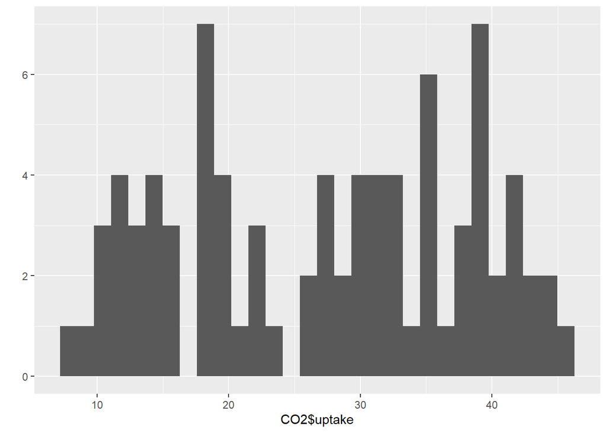

```r
# outcome
qplot(CO2$uptake)
```

- I provide this visualization to understand the true data generating process for this model (the ‘correct’ model)

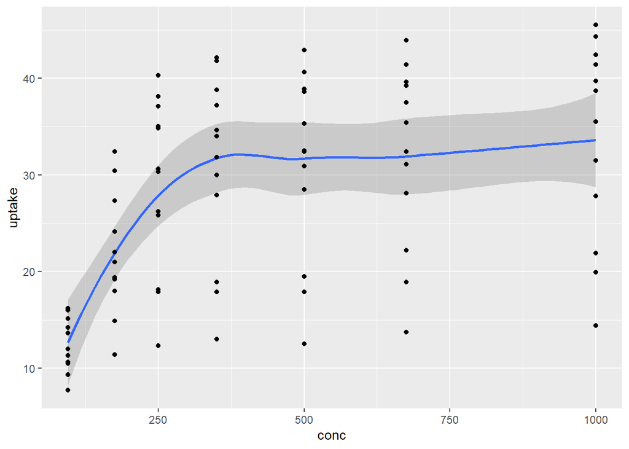

```r
# Show the relationships
ggplot(CO2, aes(conc, uptake)) +
  geom_smooth() + geom_point()
```

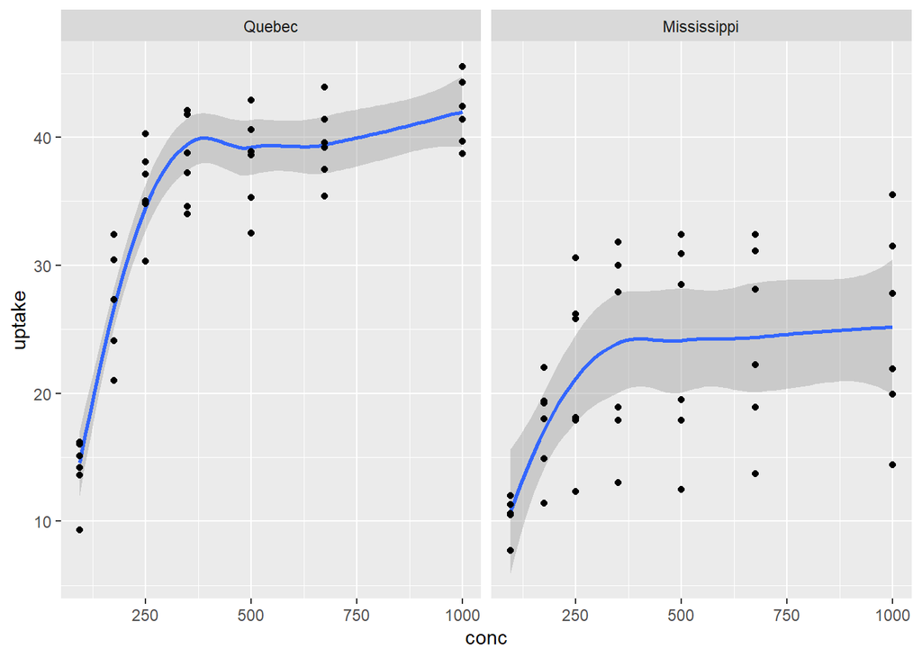

```r
# stratify by plant type
ggplot(CO2, aes(conc, uptake)) +
  geom_smooth() + geom_point() +
  facet_wrap(~ Type)
```

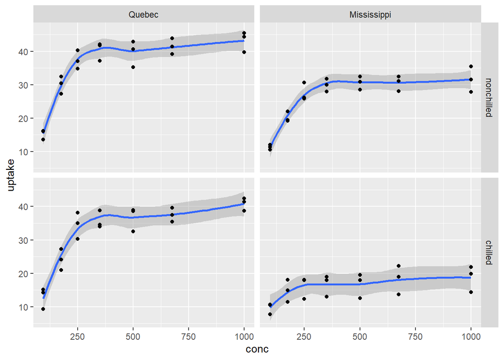

```r
# stratify by plant type and treatmet
ggplot(CO2, aes(conc, uptake)) +
  geom_smooth() + geom_point() +
  facet_grid(Treatment ~ Type)
```

- There is a non-linear relationship between concentration and uptake. The effect of treatment depends on the plant type.

# Let’s fit our first model…

- Let’s fit a basic model on the CO2 data. We will pretend we do not know the data generating process, then fit models accordingly and test to see how well they fit.
- The first model we fit should be a ‘null’ model, or just the overall mean.

```r
# Set some modeling parameters
library(rstanarm)
CHAINS = 4
SEED = 42

# Calculate overall mean
mean(CO2$uptake)
```

```
## [1] 27.2131
```

```r
# Fit basic model, specifying priors
fit0 <- stan_glm(uptake ~ 1,
                data = CO2,
                prior_intercept = normal(location = mean(CO2$uptake),
                                         scale = 4,
                                         autoscale = T),
                prior_aux = exponential(rate = 1,
                                        autoscale = T),
                chains=CHAINS,
                seed=SEED)
# Examine model results
summary(fit0)
```

```
##
## Model Info:
##  function:     stan_glm
##  family:       gaussian [identity]
##  formula:      uptake ~ 1
##  algorithm:    sampling
##  sample:       4000 (posterior sample size)
##  priors:       see help('prior_summary')
##  observations: 84
##  predictors:   1
##
## Estimates:
##               mean   sd   10%   50%   90%
## (Intercept) 27.2    1.2 25.7  27.3  28.8
## sigma       10.9    0.9  9.8  10.9  12.1
##
## Fit Diagnostics:
##            mean   sd   10%   50%   90%
## mean_PPD 27.2    1.7 25.1  27.2  29.4
##
## The mean_ppd is the sample average posterior predictive distribution of the outcome variable (for details see help('summary.stanreg')).
##
## MCMC diagnostics
##               mcse Rhat n_eff
## (Intercept)   0.0  1.0  2643
## sigma         0.0  1.0  2804
## mean_PPD      0.0  1.0  3281
## log-posterior 0.0  1.0  1545
##
## For each parameter, mcse is Monte Carlo standard error, n_eff is a crude measure of effective sample size, and Rhat is the potential scale reduction factor on split chains (at convergence Rhat=1).
```

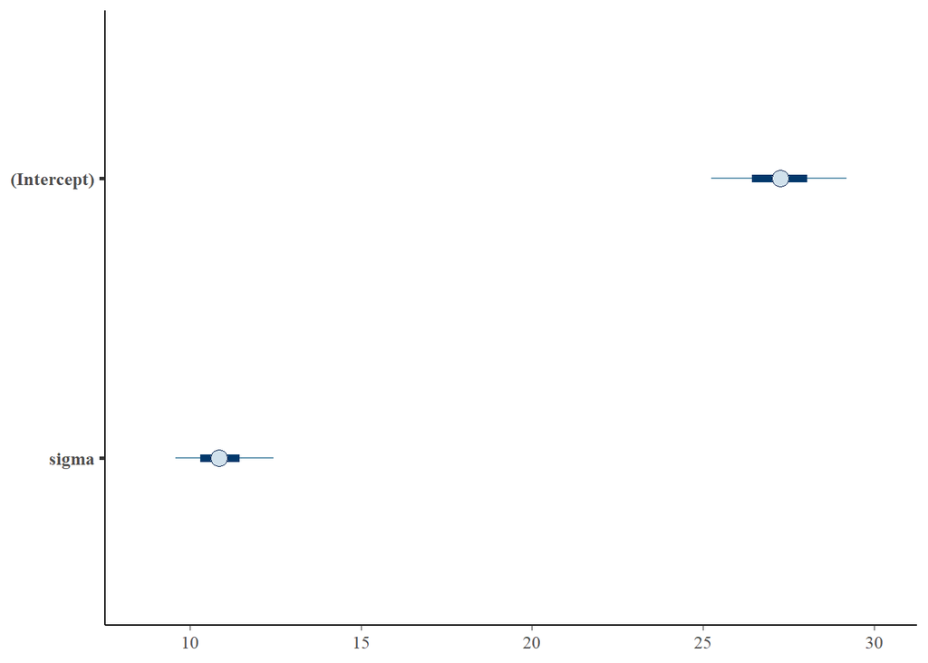

```r
plot(fit0)
```

# Interpreting the output of this model

- We have estimated the null model, which essentially just means we estimated the mean of the distribution. This is likely a good estimate of the overall mean, but we can do better than this! (assuming there is some predictive power to be gained from the predictors)
- Recall we can summarize the posterior predictions easily with some code like this:

```r
# Mean of the posterior
mean(as.data.frame(fit0)$`(Intercept)`)
```

```
## [1] 27.22994
```

```r
# Median
median(as.data.frame(fit0)$`(Intercept)`)
```

```
## [1] 27.25154
```

```r
# same as the coef (median)
coef(fit0)
```

```
## (Intercept)
##    27.25154
```

- We can also ask about probabilities of the posterior distribution in the usual manner:

```r
# probability that sample mean is less than 25
sum(as.data.frame(fit0)$`(Intercept)`<25) / length(as.data.frame(fit0)$`(Intercept)`)
```

```
## [1] 0.03625
```

# How good is this model?

- let’s take a few moments to review the output and talk through the summary statistics.
- The sample size is the number of samples (post warm up)
- The table of estimates is a standard table summarizing the posterior for each estimate
- The fit diagnostic reported here is the `mean_PPD`. This is the mean of the posterior distribution. Ideally this will be close to the sample mean!
- The MCMC diagnostics summarize how well the MCMC algorithm worked / converged. We will cover this in more depth later.

```r
# Check
summary(fit0)
```

```
##
## Model Info:
##  function:     stan_glm
##  family:       gaussian [identity]
##  formula:      uptake ~ 1
##  algorithm:    sampling
##  sample:       4000 (posterior sample size)
##  priors:       see help('prior_summary')
##  observations: 84
##  predictors:   1
##
## Estimates:
##               mean   sd   10%   50%   90%
## (Intercept) 27.2    1.2 25.7  27.3  28.8
## sigma       10.9    0.9  9.8  10.9  12.1
##
## Fit Diagnostics:
##            mean   sd   10%   50%   90%
## mean_PPD 27.2    1.7 25.1  27.2  29.4
##
## The mean_ppd is the sample average posterior predictive distribution of the outcome variable (for details see help('summary.stanreg')).
##
## MCMC diagnostics
##               mcse Rhat n_eff
## (Intercept)   0.0  1.0  2643
## sigma         0.0  1.0  2804
## mean_PPD      0.0  1.0  3281
## log-posterior 0.0  1.0  1545
##
## For each parameter, mcse is Monte Carlo standard error, n_eff is a crude measure of effective sample size, and Rhat is the potential scale reduction factor on split chains (at convergence Rhat=1).
```

- This all looks good! Convergence worked. However, does that mean we have a good model? Let’s investigate the posterior predictions (subject level) and compare that distribution to the actual data distribution.

```r
library(bayesplot)
# examine the predicted values
posterior_predictions <-
  posterior_predict(fit0) # don't need predictors for null model
# one column for each observation (84), one row for each chain element (4000)
str(posterior_predictions)
```

```
##  'ppd' num [1:4000, 1:84] 27.3 41.5 28.1 21.4 21 ...
##  - attr(*, "dimnames")=List of 2
##   ..$ : NULL
##   ..$ : chr [1:84] "1" "2" "3" "4" ...
```

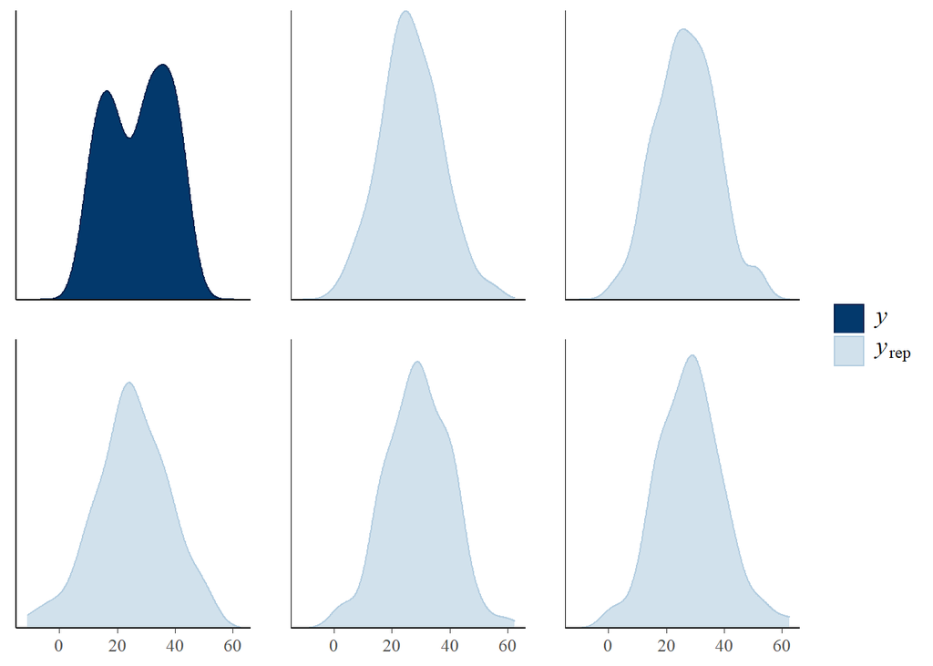

```r
# Plotting function from bayesplot to examine the outcomes
ppc_dens(y = CO2$uptake,
         yrep = posterior_predictions[1:5,])
```

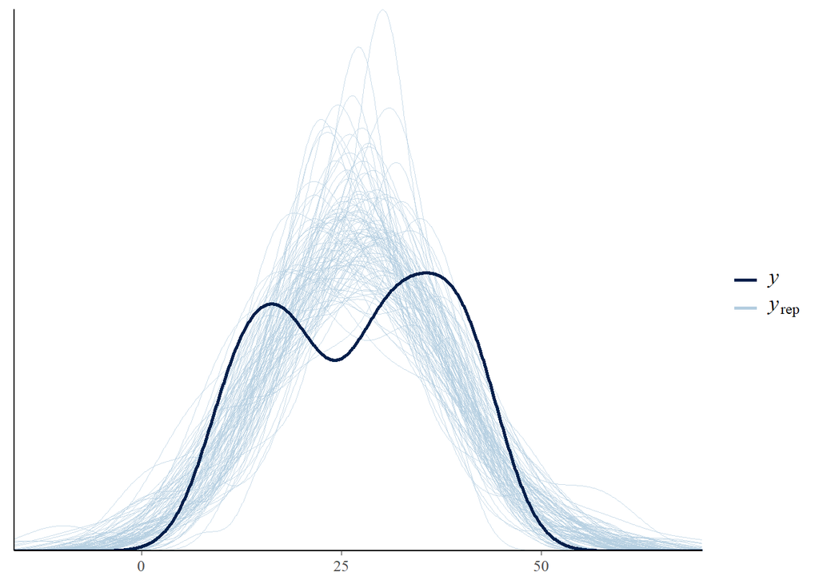

```r
# Overlay multiple densities (first 100) - doing all of them takes awhile
ppc_dens_overlay(y = CO2$uptake,
         yrep = posterior_predictions[1:100,])
```

- What do you think of the observed Y compared to the posterior Y reps?
- It looks like the observed Y is bi-modal, but we are not getting that same behavior in the y reps (simulations from the posterior). This implies the specified model does not do a good job of describing the underlying population.
- Interestingly, we are still effectively estimating the mean (because of the central limit theorem!). But this is a good indicator that the model is not accurately representing the data generating process beyond the sample mean.
- We could check the residuals and see the same thing - the residuals seem bimodally distributed

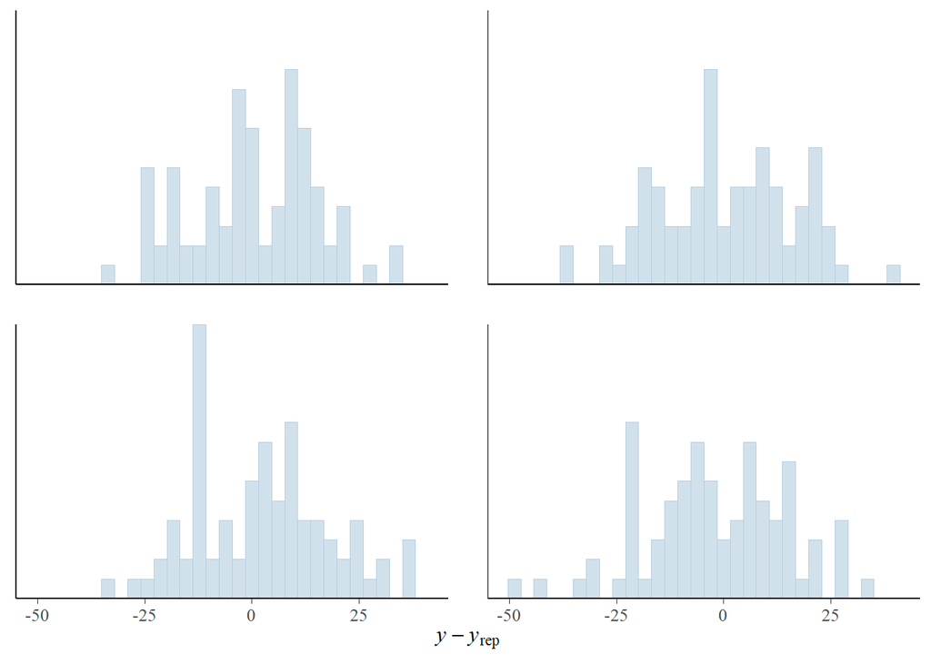

```r
# Check residuals plots
ppc_error_hist(y = CO2$uptake,
         yrep = posterior_predictions[1:4,])
```

- Lets make a bit more complex model and see how it fares.

# Add One Predictor

- One of the variables in the dataset is the concentration of CO2 (conc). Perhaps the uptake by a given plant is influenced by the concentration of CO2 present. We will add that into our model.

```r
# Fit model with concentration, allow default prior
fit1 <- stan_glm(uptake ~ conc,
                data = CO2,
                chains=CHAINS,
                seed=SEED)
# Check priors
prior_summary(fit1)
```

```
## Priors for model 'fit1'
## ------
## Intercept (after predictors centered)
##   Specified prior:
##     ~ normal(location = 27, scale = 2.5)
##   Adjusted prior:
##     ~ normal(location = 27, scale = 27)
##
## Coefficients
##   Specified prior:
##     ~ normal(location = 0, scale = 2.5)
##   Adjusted prior:
##     ~ normal(location = 0, scale = 0.091)
##
## Auxiliary (sigma)
##   Specified prior:
##     ~ exponential(rate = 1)
##   Adjusted prior:
##     ~ exponential(rate = 0.092)
## ------
## See help('prior_summary.stanreg') for more details
```

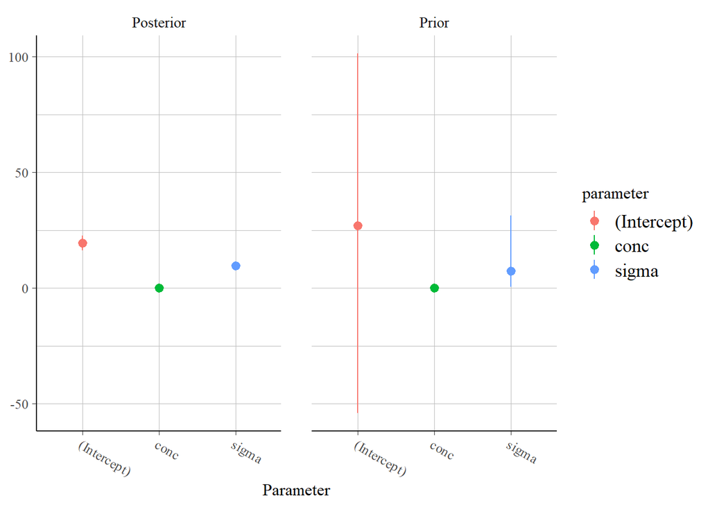

```r
posterior_vs_prior(fit1)
```

```r
# Examine model results
summary(fit1,digits=3)
```

```
##
## Model Info:
##  function:     stan_glm
##  family:       gaussian [identity]
##  formula:      uptake ~ conc
##  algorithm:    sampling
##  sample:       4000 (posterior sample size)
##  priors:       see help('prior_summary')
##  observations: 84
##  predictors:   2
##
## Estimates:
##               mean   sd     10%    50%    90%
## (Intercept) 19.537  1.883 17.094 19.573 21.992
## conc         0.018  0.004  0.013  0.018  0.022
## sigma        9.625  0.764  8.690  9.577 10.608
##
## Fit Diagnostics:
##            mean   sd     10%    50%    90%
## mean_PPD 27.214  1.483 25.310 27.224 29.124
##
## The mean_ppd is the sample average posterior predictive distribution of the outcome variable (for details see help('summary.stanreg')).
##
## MCMC diagnostics
##               mcse  Rhat  n_eff
## (Intercept)   0.030 0.999 3910
## conc          0.000 1.000 3947
## sigma         0.012 1.000 4109
## mean_PPD      0.024 1.000 3899
## log-posterior 0.030 1.000 1672
##
## For each parameter, mcse is Monte Carlo standard error, n_eff is a crude measure of effective sample size, and Rhat is the potential scale reduction factor on split chains (at convergence Rhat=1).
```

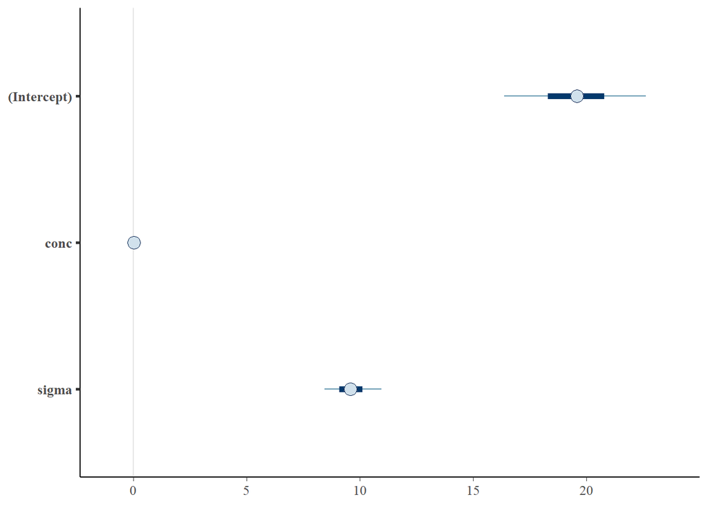

```r
plot(fit1)
```

- It looks like conc is significantly associated with the outcome - the probability that the coefficient for concentration is above 0 is:

```r
# Prob is 0.9999999
sum(as.data.frame(fit1)$conc>0)/length(as.data.frame(fit1)$conc>0)
```

```
## [1] 1
```

```r
# check the quantiles
quantile(as.data.frame(fit1)$conc,probs = c(0,0.01,0.05,0.1,0.9,0.95,0.99,1))
```

```
##          0%          1%          5%         10%         90%         95%         99%        100%
## 0.004356411 0.009427263 0.011824092 0.012987486 0.022254317 0.023603180 0.026105759 0.029252614
```

# Check the posterior

- Let’s run some plots to check the posterior distribution of Y compared to the observed y.

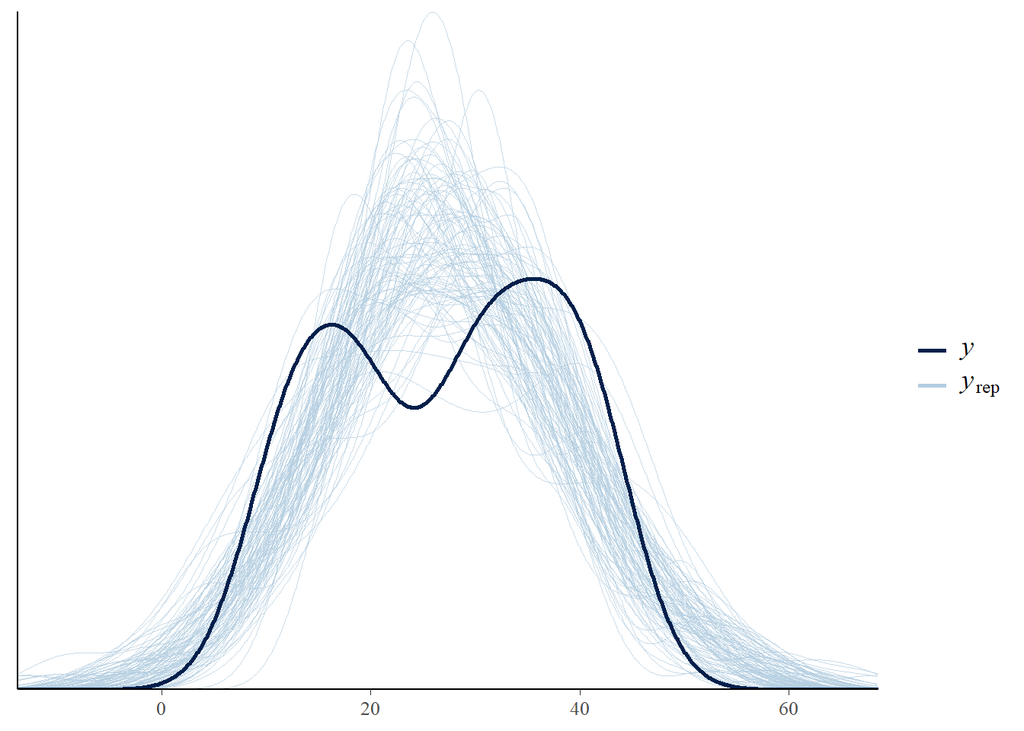

```r
# Overlay multiple densities (first 100) - doing all of them takes awhile
ppc_dens_overlay(y = CO2$uptake,
         yrep = posterior_predict(fit1)[1:100,])
```

- We still have the bimodal issue - a linear term for conc did not fix this.

# Model we just fit from frequentist view

- How might we further investigate the object we just fit?
- Here is the model we just fit from a frequentist perspective:

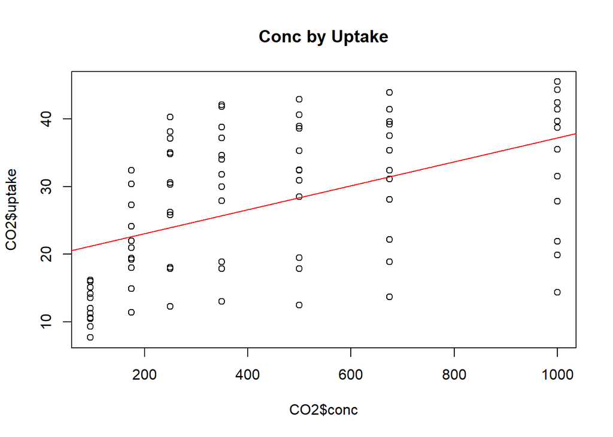

```r
plot(CO2$conc, CO2$uptake, main = "Conc by Uptake")
# add the line of best fit using least squares estimate
abline(lm(uptake ~ conc,
          data=CO2),col="red")
```

# Exploring model results from Bayesian perspective

- Since we used a Bayesian approach with MCMC, We just found a range of reasonable values for the parameter estimates (the posterior). How might we view the full range of results?
- We can extract the MCMC chains from the fit object into a dataframe, then plot all of them to understand what the results of our model looks like.

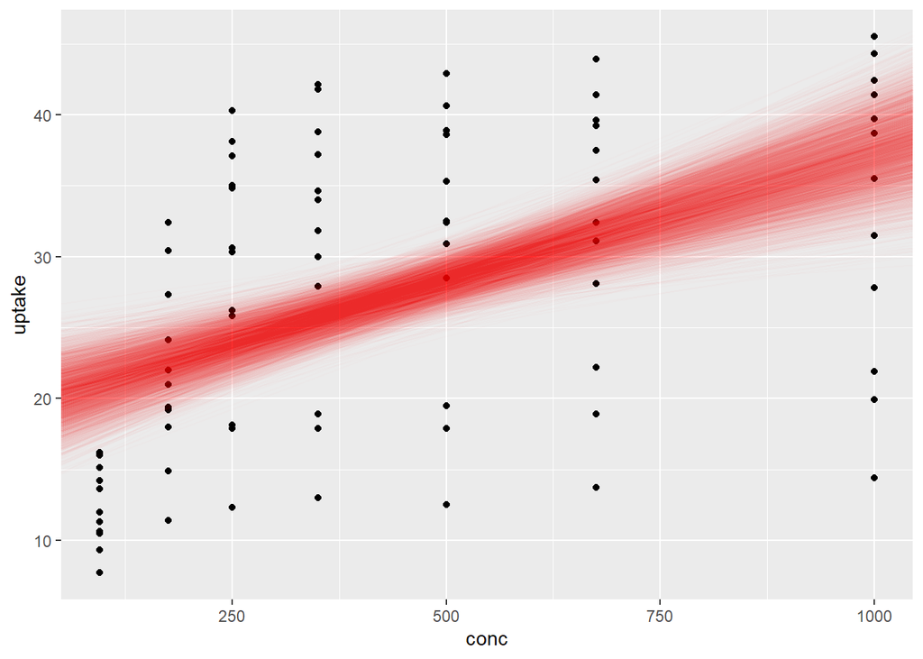

```r
posterior1 <- as.data.frame(fit1)
names(posterior1)[1] <- "intercept"
library(ggplot2)
ggplot(CO2, aes(conc,uptake)) +
  geom_point() +
  geom_abline(data = posterior1,
              color='red',alpha=0.01,
              aes(slope = conc,
              intercept=intercept)
              )
```

- How well does this model fit the data?
- Where is it a good fit, or a bad fit?

# Model evaluation: Residuals

- How familiar are you with the concept of residual analysis to analyze model fit?
- We can calculate and view the residuals. For a good model fit, what should the distribution of the residuals be?
- First we must calculate an expected value based on our model, then we can calculate the difference (the residual).

```r
# Get predictions for each observation
fit1_pred <- posterior_linpred(fit1)
str(fit1_pred)
```

```
##  num [1:4000, 1:84] 21.5 21.5 23.8 23.6 23.7 ...
##  - attr(*, "dimnames")=List of 2
##   ..$ iterations: NULL
##   ..$           : chr [1:84] "1" "2" "3" "4" ...
```

```r
class(fit1_pred)
```

```
## [1] "matrix"
```

```r
dim(fit1_pred)
```

```
## [1] 4000   84
```

```r
# Get median value for each observation
median(fit1_pred[,1])
```

```
## [1] 21.23491
```

```r
median(fit1_pred[,2]) # and so on
```

```
## [1] 22.63238
```

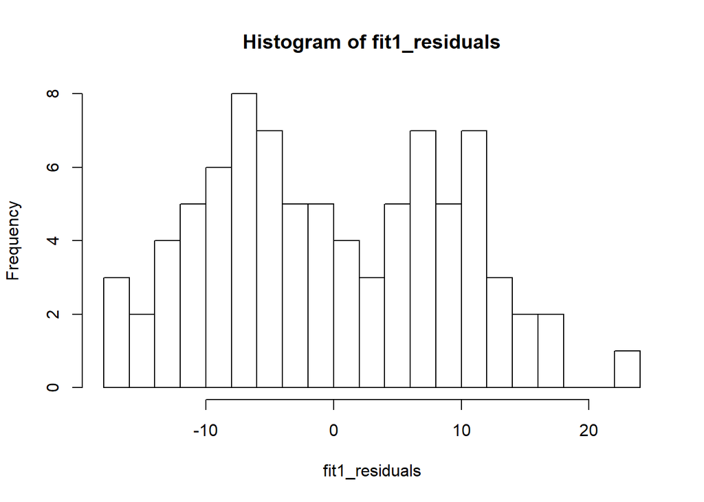

```r
# Get all at once with apply statement
fit1_pred_med <- apply(fit1_pred,2,median)
# Compare predictions to actual values
fit1_residuals <- fit1_pred_med - CO2$uptake
hist(fit1_residuals,breaks = 20)
```

# Model evaluation: Residual Analysis

- What if the model is systematically wrong as a function of the predictor value…what does that imply about the functional form of our model?

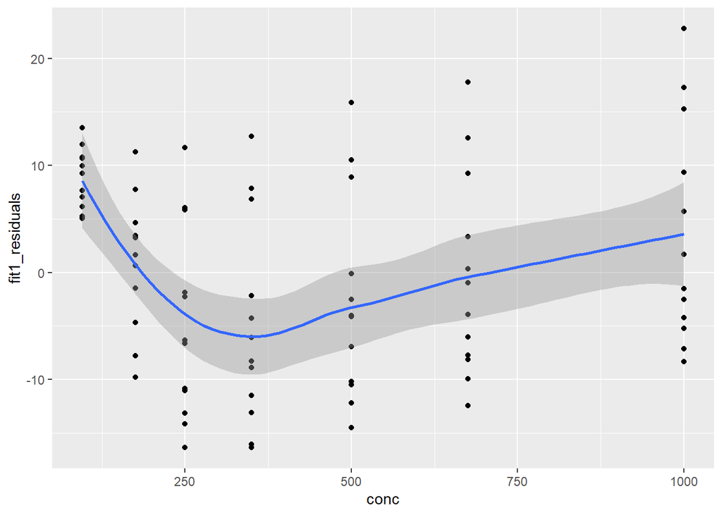

```r
# Create a new dataframe with these values
fit1_CO2 <- data.frame(uptake=CO2$uptake,
                       conc=CO2$conc,
                       fit1_pred_med,
                       fit1_residuals)
# Plot the residuals against the conc predictor
ggplot(fit1_CO2,aes(conc,fit1_residuals)) +
  geom_point() +
  geom_smooth()
```

# Polynomial regression

- What if my outcome is not a linear function of my predictor?
- Recall our assumption of linearity
- Why is it still “linear regression”? Because it is linear in the predictors…

```r
# Fit model with concentration, specifying priors
fit2 <- stan_glm(uptake ~ conc + I(conc^2),
                data = CO2,
                chains=CHAINS,
                seed=SEED)
# Check priors
prior_summary(fit1)
```

```
## Priors for model 'fit1'
## ------
## Intercept (after predictors centered)
##   Specified prior:
##     ~ normal(location = 27, scale = 2.5)
##   Adjusted prior:
##     ~ normal(location = 27, scale = 27)
##
## Coefficients
##   Specified prior:
##     ~ normal(location = 0, scale = 2.5)
##   Adjusted prior:
##     ~ normal(location = 0, scale = 0.091)
##
## Auxiliary (sigma)
##   Specified prior:
##     ~ exponential(rate = 1)
##   Adjusted prior:
##     ~ exponential(rate = 0.092)
## ------
## See help('prior_summary.stanreg') for more details
```

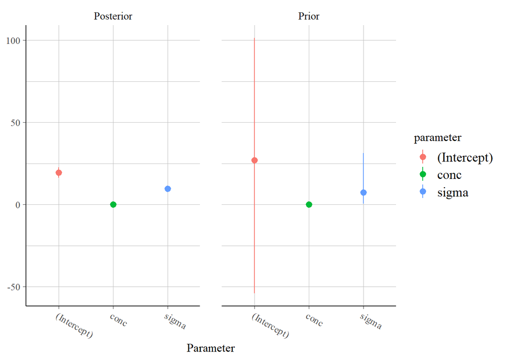

```r
posterior_vs_prior(fit1)
```

```r
# Examine model results
summary(fit2,digits=5)
```

```
##
## Model Info:
##  function:     stan_glm
##  family:       gaussian [identity]
##  formula:      uptake ~ conc + I(conc^2)
##  algorithm:    sampling
##  sample:       4000 (posterior sample size)
##  priors:       see help('prior_summary')
##  observations: 84
##  predictors:   3
##
## Estimates:
##               mean     sd       10%      50%      90%
## (Intercept) 11.17452  2.95879  7.39405 11.23004 14.93158
## conc         0.06380  0.01340  0.04662  0.06395  0.08062
## I(conc^2)   -0.00004  0.00001 -0.00006 -0.00004 -0.00003
## sigma        8.95591  0.72456  8.06862  8.90085  9.93685
##
## Fit Diagnostics:
##            mean     sd       10%      50%      90%
## mean_PPD 27.16238  1.38650 25.39502 27.14052 28.91709
##
## The mean_ppd is the sample average posterior predictive distribution of the outcome variable (for details see help('summary.stanreg')).
##
## MCMC diagnostics
##               mcse    Rhat    n_eff
## (Intercept)   0.06867 1.00059 1857
## conc          0.00033 1.00051 1664
## I(conc^2)     0.00000 1.00027 1647
## sigma         0.01564 1.00129 2147
## mean_PPD      0.02595 1.00086 2856
## log-posterior 0.03733 1.00024 1419
##
## For each parameter, mcse is Monte Carlo standard error, n_eff is a crude measure of effective sample size, and Rhat is the potential scale reduction factor on split chains (at convergence Rhat=1).
```

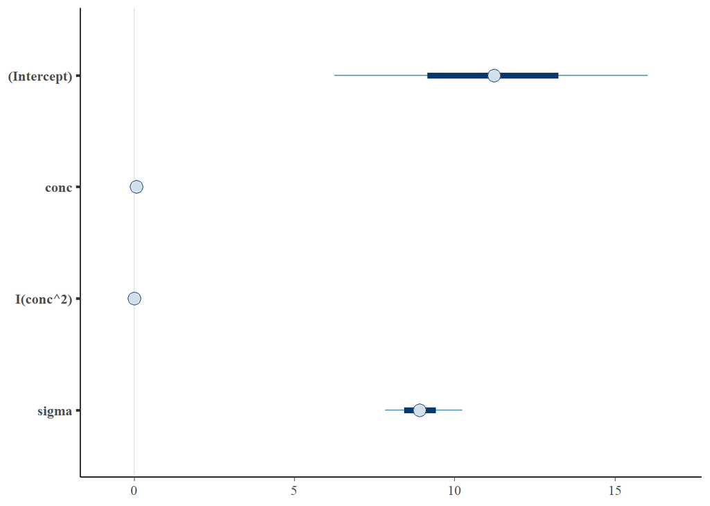

```r
plot(fit2)
```

- How do we know if the polynomial is providing a better fit?
  - Examine the higher-order term.
- In this model, we use `I()` to indicate a variable transformation. We also could have created another variable in the dataframe that is conc squared and used that, but this is shorter.